# Data Notes

Answering the question, “just what’s in this set, exactly?”

```r
manifest <- read.delim("E:\\Leaf_PCA_data\\leafsnap-dataset-images.txt", header = TRUE)
```

```r
# Count how many images do and don't have "segmented" in their path.
columns_names <- manifest %>%
  colnames()

number_rows <- manifest %>%
  nrow()

columns_names
```

```
[1] "file_id"        "image_path"     "segmented_path" "species"        "source"
```

```r
number_rows
```

```
[1] 30866
```

What’s the most common size of image?

```r
sample_photo_paths <- sample(manifest$segmented_path, 200)
dimensions = c()

for (photo in photo_sample_paths) {
  path = file.path("E:/Leaf_PCA_data", photo)
  d <- dim(readPNG(path))
  dimensions = c(label, paste(d, collapse = " "))
}
```

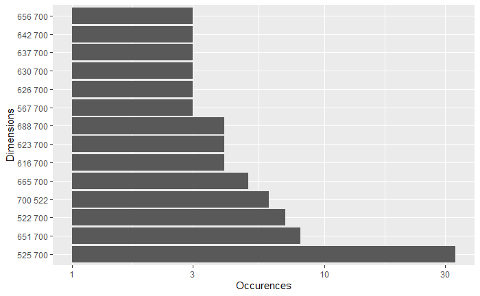

```r
tibble(label = dimensions) %>%
  count(label) %>%
  mutate(label = fct_reorder(label, n, .desc = TRUE)) %>%
  top_n(10) %>%
  ggplot(aes(x = n, y = label)) +
  scale_x_log10() +
  xlab("Occurences") +
  ylab("Dimensions") +
  geom_col()
```

Ok, fine, maybe there’s a folder of only this size. Let’s append the dimensions of each segmented photo to the overall data frame, and use that to pick out some common dimension to test with.

```r
x_dim <- c()
y_dim <- c()
for (photo in manifest$segmented_path[]) {
  path = file.path("E:/Leaf_PCA_data", photo)
  d <- dim(readPNG(path))
  x_dim <- c(x_dim, d[[1]])
  y_dim <- c(y_dim, d[[2]])
}
```

Cool, lets check the dimensions of this thing. Exactly what here needs to be fixed before the final analysis?

First off, how many images are there that are all the same size?

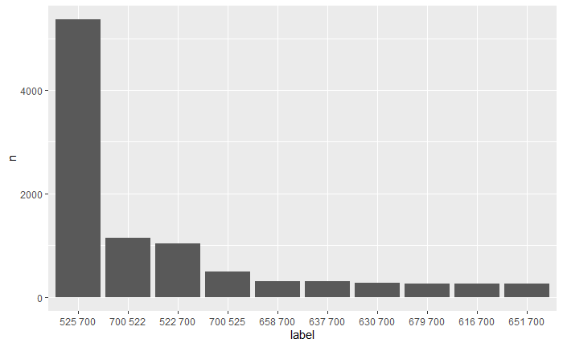

```r
manifest_new <- readRDS("../data/updated_leafsnap-dataset-images.Rds")
manifest_new %>%
  mutate(label = paste(x_dim, y_dim, sep = " ")) %>%
  group_by(label) %>%
  summarize(n = n()) %>%
  top_n(10) %>%
  mutate(label = fct_reorder(label, n, .desc = TRUE)) %>%
  ggplot(aes(x = label, y = n)) +
  geom_col()
```

Ok, very cool. We’ve got about 5000 photos that we won’t have to resize just yet. Lets work with those.

```r
test_set <- manifest_new %>%
  filter(x_dim == 525, y_dim == 700) %>%
  mutate(path_full = file.path("E:/Leaf_PCA_data", segmented_path)) %>%
  select(path_full) %>%
  as.vector()

saveRDS(test_set, "../data/test_set.Rds")
```

How on earth can I extract the pixel data that I’m looking for? Trying to get a greyscale value for each pixel that’s between 0 and 1. Let’s convert the pixel matrix to a vector by row. Also make sure that each row is appended to themselves in the correct way.

```r
# List-ify the tranposed matrix.
pixel_vector <- c(t(photo_raw))

row_is_correct <- c()
for (n in 0:(500-1)) {
  correct <- all(photo_raw[n,] == pixel_vector[(700*(n-1)+1):(700*n)])
  row_is_correct <- c(correct, row_is_correct)
}
all(row_correct_log)
```

```
[1] TRUE
```

Ok, the pixel thing works. Wait, do all of my images have 1 channel that’s either 1 or 0?

```r
photo_paths <- readRDS("../data/test_set.Rds")
sample_photo_paths <- sample(photo_paths$path_full, 200)
time_in <- Sys.time()

all_photos_correct <- c()
for (photo in sample_photo_paths) {
  photo_data <- readPNG(photo)
  pixel_vector <- c(t(photo_data))
  correct <- (pixel_vector == 0) | (pixel_vector == 1)
  all_photos_correct <- c(all_photos_correct, correct)
}
all(all_photos_correct)
```

```
[1] TRUE
```

```r
Sys.time() - time_in
```

```
Time difference of 32.15076 secs
```

Cool, now we’ve got photos of the same size and color type.

```r
data_mat <- matrix(nrow = 200, ncol = 525*700)
for (i in 1:length(sample_photo_paths)) {
  photo_data <- readPNG(sample_photo_paths[[i]])
  data_mat[i,] <- c(t(photo_data))
}
```

Calculate the covariance matrix.

```r
mat_1 <- matrix(data=1,nrow=200,ncol=200)
x_mat <- data_mat - ((mat_1 %*% data_mat) * (1 / 200))
covar_mat <- (x_mat %*% t(x_mat)) * (1/200)
```

```r
eig_object <- eigs_sym(covar_mat, k=3, which = "LM")
eig_object
```

```
$values
[1] 9016.938 2414.818 1782.198

$vectors
               [,1]          [,2]          [,3]
  [1,] -0.070439926 -1.487472e-01 -0.0907231602
  [2,] -0.022919285  2.322188e-01 -0.1001053111
  [3,]  0.070878563 -1.620409e-02  0.0358155510
  [4,] -0.122005806  5.270842e-02 -0.1242006452
  [5,] -0.017665511  4.080496e-02  0.1663198750
  [6,] -0.008045559 -2.875410e-02  0.0995310657
  [7,] -0.045295485 -7.650973e-02  0.0762042671
  [8,] -0.029814511  2.649485e-01 -0.1071495427
  [9,] -0.030574381 -1.703377e-02 -0.0356544923
 [10,]  0.081249376 -3.182528e-02  0.0221243291
```

[output cut: 199 more lines]

Anything to analyze in these vectors? Can we represent them as images?

```r
round(eig_object$vectors)
```

```
       [,1] [,2] [,3]
  [1,]    0    0    0
  [2,]    0    0    0
  [3,]    0    0    0
  [4,]    0    0    0
  [5,]    0    0    0
  [6,]    0    0    0
  [7,]    0    0    0
  [8,]    0    0    0
  [9,]    0    0    0
 [10,]    0    0    0
 [11,]    0    0    0
 [12,]    0    0    0
 [13,]    0    0    0
 [14,]    0    0    0
```

[output cut: 186 more lines]

Nope, just not a whole lot of data that was extracted. Now, how can I center each of these images for further processing???

WAIT, FORGOT TO CENTER THE IMAGES BEFORE CALCULATING STUFF

You know what? Let’s try something in C++ to re-border all off the images in a black frame. First off, we need to know the maximum sizes that we’re dealing with. Two choices, either resize all of these, or just add a black boarder. I’m leading towards the latter, because I don’t want to distort my data more than I have to.

```r
manifest_new <- readRDS("../data/updated_leafsnap-dataset-images.Rds")
manifest_new %>%
  summarize(x_MAX = max(x_dim), x_MIN = min(x_dim), y_MAX = max(y_dim), y_MIN = min(y_dim))
```

| x_MAX | x_MIN | y_MAX | y_MIN |
| --- | --- | --- | --- |
| 700 | 265 | 700 | 287 |

Wait, are all of these photo even PNGs? Answer: The segmented ones are, but the lab photos are not. Make a note of that for later conversions.

```r
manifest <- read.delim("E:\\Leaf_PCA_data\\leafsnap-dataset-images.txt", header = TRUE)
manifest %>%
  mutate(is_PNG = str_detect(segmented_path, ".png|.PNG")) %>%
  count(is_PNG)
```

| is_PNG | n |
| --- | --- |
| TRUE | 30866 |

Next question, how am I going to walk this directory, converting all the images as I go? Answer: Separate R script. Ok, done. Let’s assemble a better matrix Let’s do a test on part of our photo set. There’s a lot of photos. We should have an answer to “How many seconds per photos?” and “Does this number increase as the matrix gets larger?”

```r
folders <- list.dirs("E:\\Leaf_PCA_data\\2021-12-04_segmented_RESIZED")[-1][1:2]

# Initialize data collection vector.
timing_vec <- c()
# 324 photos to add to matrix
data_mat <- matrix(nrow = 324, ncol = 700*700)
for (dir in folders) {
  files <- list.files(dir, full.names = TRUE)

  for (i in 1:length(files)) {
    time_in <- Sys.time()

    photo_data <- readPNG(files[[i]])
    data_mat[i,] <- c(t(photo_data))

    diff <- difftime(Sys.time(), time_in, units = "secs")
    timing_vec <- c(timing_vec, diff)
  }
}
data_mat[1:10,1:10]
```

```
      [,1] [,2] [,3] [,4] [,5] [,6] [,7] [,8] [,9] [,10]
 [1,]    0    0    0    0    0    0    0    0    0     0
 [2,]    0    0    0    0    0    0    0    0    0     0
 [3,]    0    0    0    0    0    0    0    0    0     0
 [4,]    0    0    0    0    0    0    0    0    0     0
 [5,]    0    0    0    0    0    0    0    0    0     0
 [6,]    0    0    0    0    0    0    0    0    0     0
 [7,]    0    0    0    0    0    0    0    0    0     0
 [8,]    0    0    0    0    0    0    0    0    0     0
 [9,]    0    0    0    0    0    0    0    0    0     0
[10,]    0    0    0    0    0    0    0    0    0     0
```

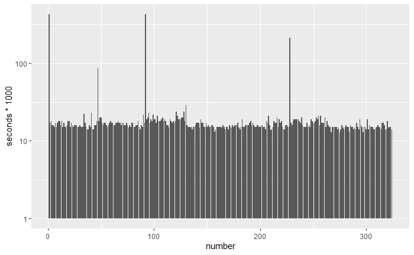

```r
avg_sec <- mean(timing_vec)
tibble(number = 1:length(timing_vec), seconds = timing_vec) %>%
  ggplot(aes(x = number, y = seconds * 1000)) +
  scale_y_log10() +
  geom_col()
```

Ok, got average time to add an image row. Also, doesn’t look like it increases with the size of the matrix. Just how long is this thing going to take?

```r
num_files <- list.files("E:\\Leaf_PCA_data\\2021-12-04_segmented_RESIZED", recursive = TRUE) %>% length()
(num_files*avg_sec)/60
```

```
[1] 7.693369
```

Seven minutes, not too bad. Pretty straightforward to add everything to the matrix for the almost-final PCA. Let’s see how this goes!

```r
path <- "E:\\Leaf_PCA_data\\2021-12-04_segmented_RESIZED"
files <- list.files(path, all.files = TRUE, recursive = TRUE, full.names = TRUE)
sample_files = sample(files, size = 400)
n_rows <- length(sample_files)
n_rows
```

```
[1] 400
```

```r
data_mat_final <- matrix(nrow = n_rows, ncol = 700*700)

for (i in 1:length(sample_files)) {
  photo_data <- readPNG(files[[i]])
  data_mat_final[i,] <- c(t(photo_data))
}
data_mat_final[1:10,1:10]
```

```
      [,1] [,2] [,3] [,4] [,5] [,6] [,7] [,8] [,9] [,10]
 [1,]    0    0    0    0    0    0    0    0    0     0
 [2,]    0    0    0    0    0    0    0    0    0     0
 [3,]    0    0    0    0    0    0    0    0    0     0
 [4,]    0    0    0    0    0    0    0    0    0     0
 [5,]    0    0    0    0    0    0    0    0    0     0
 [6,]    0    0    0    0    0    0    0    0    0     0
 [7,]    0    0    0    0    0    0    0    0    0     0
 [8,]    0    0    0    0    0    0    0    0    0     0
 [9,]    0    0    0    0    0    0    0    0    0     0
[10,]    0    0    0    0    0    0    0    0    0     0
```

```r
saveRDS(data_mat_final,
        file="..\\data\\segmented_picture_mat.Rds")
```

Ok, we’ve go a larger and more varied sample now, lets see what we can get.

```r
mat_1 <- matrix(data=1,nrow=700*700,ncol=700*700)
```

```
Error: cannot allocate vector of size 1788.9 Gb
```

Ok, looks like we’ve made some improper assumptions. Mainly, that we won’t have to do any downsampling. Huh.

1. Look into ways to represent the data more efficiently (Matrix package)
2. Carefully choose the method of down-sampling your photos, as to keep them centers the best you can, and to generalize to new photos in the future.
3. Design your cleaning script to NOT throw away all the useful information contained in the manifest. Why on earth are you using read.files so much?

# 2021-12-10

Ok, there’s basically 2 ways to go at this. Either decrease the amount of data that you’re using, or represent it in a more efficient way.

Let’s try option 2 first.

```r
install.packages("propagate")
library(propagate)
data_mat <- readRDS("..\\data\\2021-12-10_segmented_picture_mat.Rds")
cor_mat <- bigcor(data_mat, fun = "cov")
```

```
NAs introduced by coercion to integer rangeError in if (length < 0 || length > .Machine$integer.max) stop("length must be between 0 and .Machine$integer.max") :
  missing value where TRUE/FALSE needed
```